# EIA Data Updates

### Crude Oil

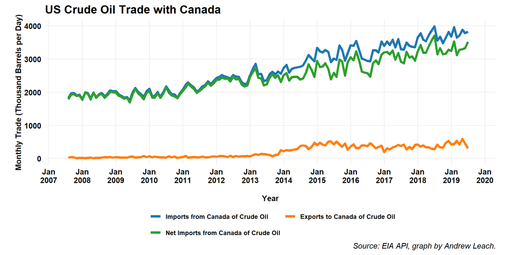

### Petroleum Products

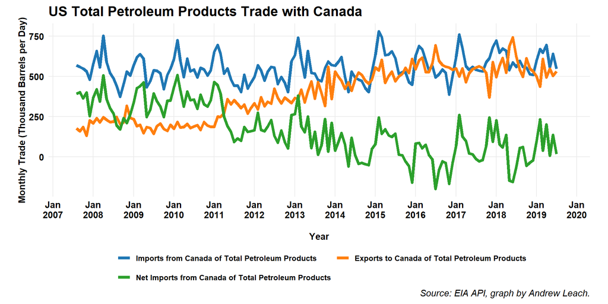

### Gasoline

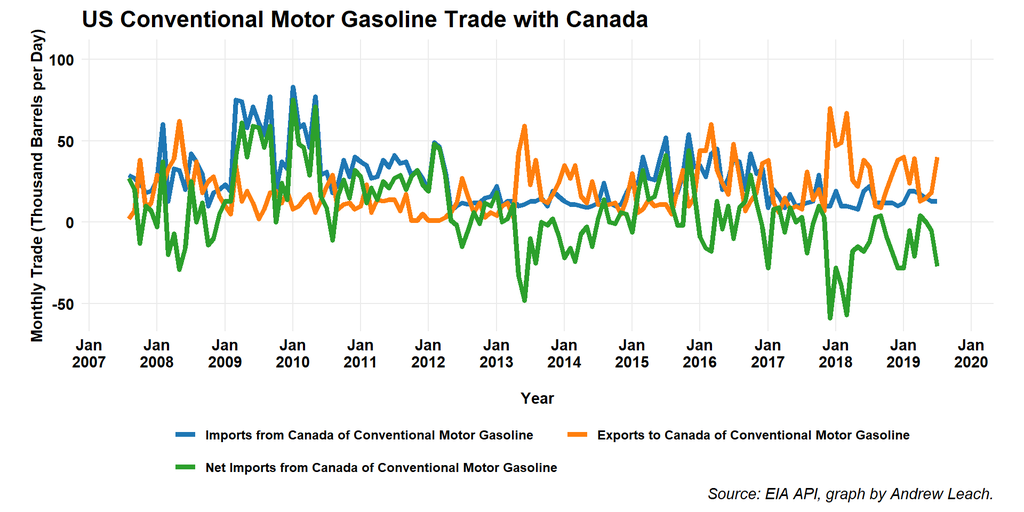

### Distillates

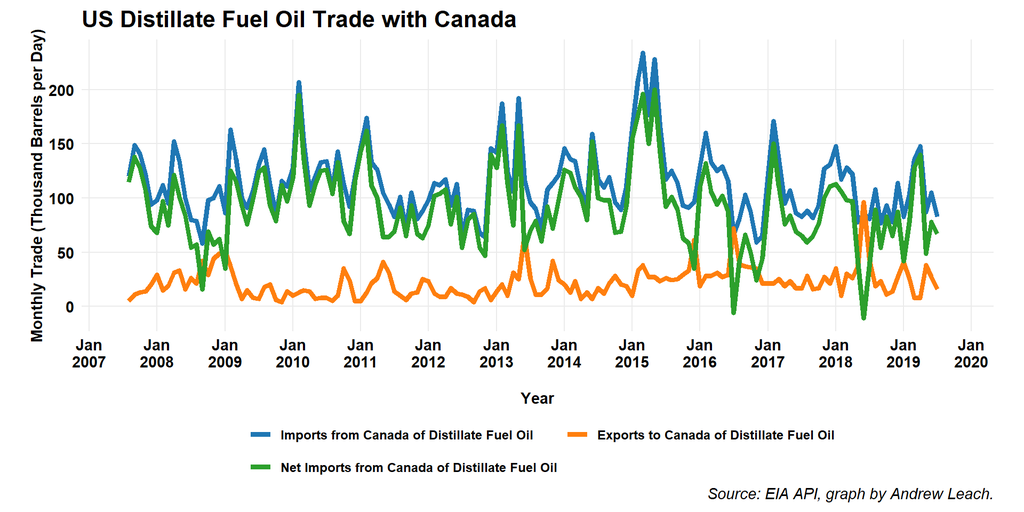

### Low Sulphur Distillates

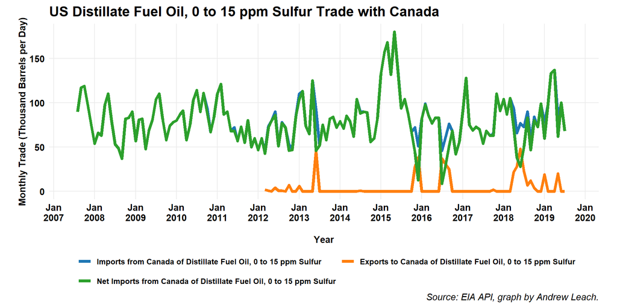

### Pentanes Plus

Pentanes plus (or natural gasoline) is a natural gas liquid used primarily in Canada as a diluent for oil sands crude.

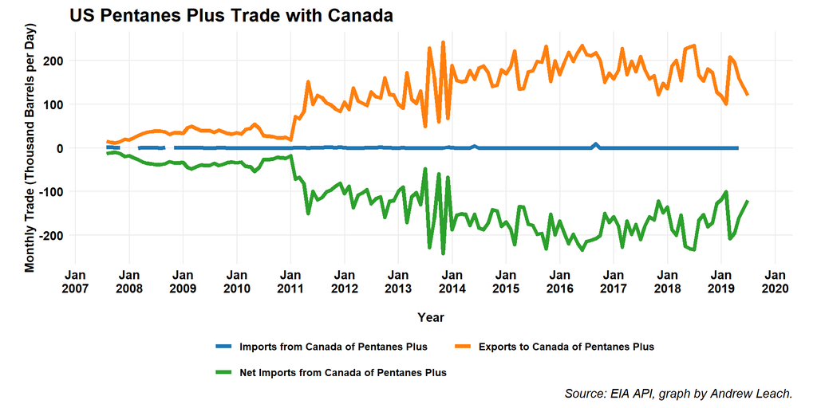

# Short Term Energy Outlook

The key data series we’ll use from the STEO are U.S. Prices, U.S. and International Petroleum and Other Liquids, and U.S. Natural Gas. For this example, let’s look at their petroleum price outlooks first.

```r
#STEO Production Outlooks
petroleum_series<-data_fetch(KEY,cat=829726)
sub_cats<-petroleum_series$Sub_Categories$category_id

data_store <- list()
stack<-1
for (cat in sub_cats) {
  #for testing
  #cat<-sub_cats$category_id[2]
  subs<-data_fetch(KEY,cat=cat)
  series <-subs$Series_IDs %>% filter(grepl("Monthly",name))#,units=="Thousand Barrels per Day")
  #series$name<-as.character(series$name)
  #series$To<-"Export"
  #series$From<-do.call("rbind",strsplit(series$name, " Exports of "))[,1]
  #series$Mode<-"Export"
  #Rest<-do.call("rbind",strsplit(series$name, " Exports of "))[,2]
  #series<-series[!grepl("Exports to",Rest),]
  #Rest<-Rest[!grepl("Exports to",Rest)] #take out exports to the PADD itself - odd
  #series$Commodity<-do.call("rbind",strsplit(Rest, ", Monthly"))[,1]
  #series$freq<-"Monthly"
  data_store[[stack]]<-series
  stack<-stack+1
}
series_proc<-data.frame(do.call(rbind,data_store),stringsAsFactors = FALSE)
series_proc<-data.frame(lapply(series_proc,as.character),stringsAsFactors = FALSE)

price_data<-data.frame(pdfetch_EIA(series_proc$series_id,KEY),stringsAsFactors = F)

price_data$date=ymd(rownames(price_data))
rownames(price_data)<-NULL
price_data<-melt(price_data,id="date",variable.name = "series_id",value.name = "price") #convert data to long form with series ids
price_data$series_id<-as.character(price_data$series_id)


price_data<-price_data %>% left_join(series_proc,by=c("series_id"="series_id")) %>%
  na.omit()%>% mutate(price=ifelse(units=="cents per gallon",price/100*42,price),
                      units=ifelse(units=="cents per gallon","dollars per barrel",units)) %>%
                filter(date>=ymd("1990-01-01"))
#adjust everything to dollars per barrel

#figure out crack spread

#add the spot price for two barrels of Gulf Coast conventional gasoline to the spot price for one barrel of Gulf Coast ultra-low sulfur diesel.

#add a 3:2:1 crack to the price
crack_data<-dcast(price_data, date ~name,value.var="price",sum)%>%
  group_by(date) %>% summarize(price=`Refiner Wholesale Gasoline Price, Monthly`*2/3+
                                 `Diesel Fuel Refiner Wholesale Price, Monthly`*1/3-
                                 `Refiner Average Crude Oil Acquisition Cost, Monthly`)%>%
  mutate(name="crack_321",
         units="dollars per barrel",
         series_id="321_crack_calculated",
         f="M",
         updated=max(price_data$updated))

price_data<-rbind(price_data,crack_data)
```

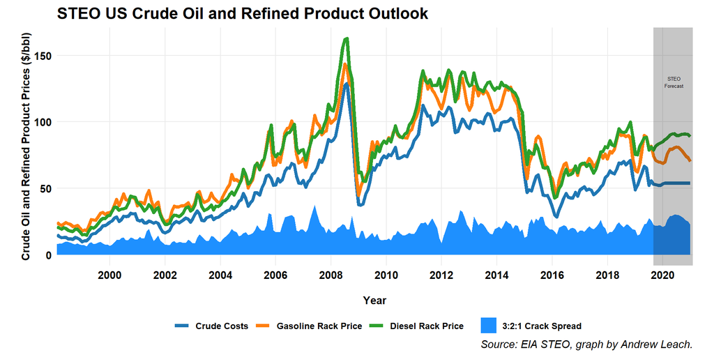

```r
series_names<-c("Refiner Average Crude Oil Acquisition Cost, Monthly",
          "Refiner Wholesale Gasoline Price, Monthly",
          "Diesel Fuel Refiner Wholesale Price, Monthly"#,
          #"Heating Oil Refiner Wholesale Price, Monthly",
          #"No. 6 Residual Fuel Oil Price, Monthly")
)
labels=c("Crude Costs", "Gasoline Rack Price", "Diesel Rack Price","3:2:1 Crack Spread")
min_forecast=dmy_hms(min(price_data$updated))
min_forecast=ymd(paste(year(min_forecast),month(min_forecast),1,sep = "-"))
max_forecast=max(price_data$date)
ggplot() +
  geom_line(data=filter(price_data,date>=ymd("1998-01-01"),name %in%series_names[1]),aes(date,price,group=name,color="A"),size=1.7) +
  geom_line(data=filter(price_data,date>=ymd("1998-01-01"),name %in%series_names[2]),aes(date,price,group=name,color="B"),size=1.7) +
  geom_line(data=filter(price_data,date>=ymd("1998-01-01"),name %in%series_names[3]),aes(date,price,group=name,color="C"),size=1.7) +
  geom_area(data=filter(price_data,date>=ymd("1998-01-01"),name =="crack_321"),aes(date,price,fill="Z")) +
  scale_color_manual("",labels=labels[1:3],values=colors_tableau10())+
  scale_fill_manual("" ,labels=labels[4],values="dodgerblue")+
  #scale_colour_brewer(NULL,labels=c("Gasoline Exports","Gasoline Imports","Net Gasoline Exports"),type = "seq", palette = "Paired", direction = 1)+
  scale_x_date(date_breaks = "2 years", date_labels =  "%Y",expand=c(0,0)) +
  guides(colour=guide_legend(nrow=1,byrow=TRUE))+
  weekly_small()+
  labs(y="Crude Oil and Refined Product Prices ($/bbl)",x="Year",
       title=paste("STEO US Crude Oil and Refined Product Outlook"),
       caption="Source: EIA STEO, graph by Andrew Leach.")+
  annotate("rect", fill = "grey10", alpha = 0.25,
           xmin = min_forecast, xmax =max_forecast+months(1), ymin = -Inf, ymax = Inf)+
  annotate("text", x = min_forecast+(max_forecast-min_forecast)/2+months(1), y = 130, label = "STEO\nForecast",size=1.75)
```

The STEO also has data on other aspects we’ll discuss in class like OPEC spare capacity and non-opec supply addtions.

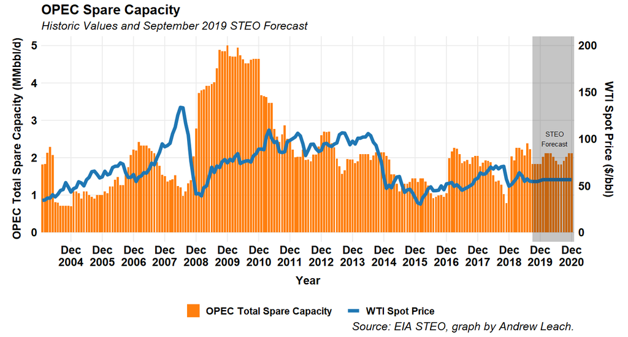

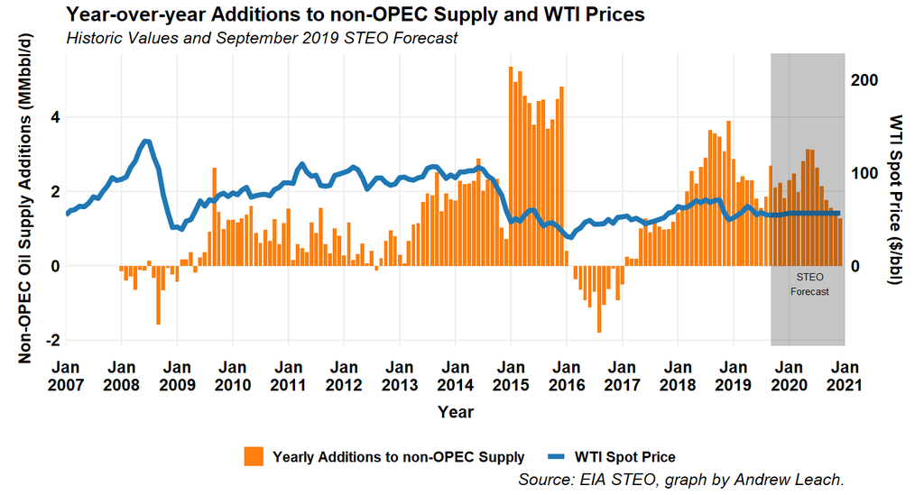

# Annual Energy Outlook

Finally, for long-term outlooks, we can look to the Annual Energy Outlook which carries forecasts through to 2050 under a variety of assumptions and scenarios. The Annual Outlook which appears twice per year (in November as an Early Release and in March in final form) is available [here](https://www.eia.gov/outlooks/aeo/) from the EIA website and, as usual, data are available for the previous 5 editions through the API [here](https://www.eia.gov/opendata/qb.php?category=964164). One of the more interesting things to do with Annual Outlook data from year to year is to see how the forward views have changed on prices or quantities in which we are interested. Below are are few examples of how the projections have evolved since 2014.

```r
oil_exports_data_19<-EIAdata::getEIA(ID = "AEO.2019.REF2019.TRAD_NA_LFL_NA_EXP_NA_USA_MILLBRLPDY.A", key = KEY)

oil_exports_data_18<-EIAdata::getEIA(ID = "AEO.2018.REF2018.TRAD_NA_LFL_NA_EXP_NA_USA_MILLBRLPDY.A", key = KEY)

oil_exports_data_17<-EIAdata::getEIA(ID = "AEO.2017.REF2017.TRAD_NA_LFL_NA_EXP_NA_USA_MILLBRLPDY.A", key = KEY)
#series_id=AEO.2017.REF2017.GEN_NA_ELEP_NA_SLR_PHTVL_NA_BLNKWH.A
oil_exports_data_16<-EIAdata::getEIA(ID = "AEO.2016.REF2016.TRAD_NA_LFL_NA_EXP_NA_USA_MILLBRLPDY.A", key = KEY)
oil_exports_data_15<-EIAdata::getEIA(ID = "AEO.2015.REF2015.TRAD_NA_LFL_NA_EXP_NA_USA_MILLBRLPDY.A", key = KEY)
oil_exports_data_14<-EIAdata::getEIA(ID = "AEO.2014.REF2014.TRAD_NA_LFL_NA_EXP_NA_USA_MILLBRLPDY.A", key = KEY)


oil_exports_data<-merge(oil_exports_data_19,oil_exports_data_18)

oil_exports_data<-merge(oil_exports_data,oil_exports_data_17)

oil_exports_data<-merge(oil_exports_data,oil_exports_data_16)
oil_exports_data<-merge(oil_exports_data,oil_exports_data_15)
oil_exports_data<-merge(oil_exports_data,oil_exports_data_14)

names(oil_exports_data)<-c("oil_exports_2019","oil_exports_2018","oil_exports_2017","oil_exports_2016","oil_exports_2015","oil_exports_2014")
oil_exports_data<-data.frame(date=index(oil_exports_data), coredata(oil_exports_data))
oil_exports_melt <- melt(oil_exports_data,id="date")

oil_exports_graph<-ggplot(oil_exports_melt) +
  geom_line(aes(date,value,colour=variable),size=2) +
  scale_color_viridis("",labels = c("2019 AEO","2018 AEO","2017 AEO","2016 AEO","2015 AEO","2014 AEO"),discrete = TRUE)+
  #scale_x_datetime(limits = lims,breaks=breaks,labels = date_format("%a\n%m-%d\n%H:00", tz="America/Denver"))+
  guides(colour=guide_legend(byrow=FALSE))+
  theme_minimal()+theme(
    legend.position = "bottom",
    legend.margin=margin(c(0,0,0,0),unit="cm"),
    legend.text = element_text(colour="black", size = 16, face = "bold"),
    plot.caption = element_text(size = 14, face = "italic"),
    plot.title = element_text(face = "bold"),
    plot.subtitle = element_text(size = 16, face = "italic"),
    panel.grid.minor = element_blank(),
    text = element_text(size = 16,face = "bold"),
    axis.text = element_text(size = 16,face = "bold", colour="black")
  )+    labs(y="Annual Oil Exports (mmbbl/d)",x="",
             title="EIA Annual Energy Outlook Oil Exports Forecasts",
             caption="Source: EIA API\nGraph by Andrew Leach")

oil_net_imports_data_19<-EIAdata::getEIA(ID = "AEO.2018.REF2018.TRAD_NA_LFL_NA_NETIMP_NETIMP_USA_MILLBRLPDY.A", key = KEY)
oil_net_imports_data_18<-EIAdata::getEIA(ID = "AEO.2019.REF2019.TRAD_NA_LFL_NA_NETIMP_NETIMP_USA_MILLBRLPDY.A", key = KEY)
oil_net_imports_data_17<-EIAdata::getEIA(ID = "AEO.2017.REF2017.TRAD_NA_LFL_NA_NETIMP_NETIMP_USA_MILLBRLPDY.A", key = KEY)
oil_net_imports_data_16<-EIAdata::getEIA(ID = "AEO.2016.REF2016.TRAD_NA_LFL_NA_NETIMP_NETIMP_USA_MILLBRLPDY.A", key = KEY)
oil_net_imports_data_15<-EIAdata::getEIA(ID = "AEO.2015.REF2015.TRAD_NA_LFL_NA_NETIMP_NETIMP_USA_MILLBRLPDY.A", key = KEY)
oil_net_imports_data_14<-EIAdata::getEIA(ID = "AEO.2014.REF2014.TRAD_NA_LFL_NA_NETIMP_NETIMP_USA_MILLBRLPDY.A", key = KEY)
oil_net_imports_data<-merge(oil_net_imports_data_19,oil_net_imports_data_18)
oil_net_imports_data<-merge(oil_net_imports_data,oil_net_imports_data_17)
oil_net_imports_data<-merge(oil_net_imports_data,oil_net_imports_data_16)
oil_net_imports_data<-merge(oil_net_imports_data,oil_net_imports_data_15)
oil_net_imports_data<-merge(oil_net_imports_data,oil_net_imports_data_14)

names(oil_net_imports_data)<-c("oil_net_imports_2019","oil_net_imports_2018","oil_net_imports_2017","oil_net_imports_2016","oil_net_imports_2015","oil_net_imports_2014")
oil_net_imports_data<-data.frame(date=index(oil_net_imports_data), coredata(oil_net_imports_data))
oil_net_imports_melt <- melt(oil_net_imports_data,id="date")


oil_net_imports_graph<-ggplot(oil_net_imports_melt) +
  geom_line(aes(date,value,colour=variable),size=2) +
  scale_color_viridis("",labels = c("2019 AEO","2018 AEO","2017 AEO","2016 AEO","2015 AEO","2014 AEO"),discrete = TRUE)+
  #scale_x_datetime(limits = lims,breaks=breaks,labels = date_format("%a\n%m-%d\n%H:00", tz="America/Denver"))+
  guides(colour=guide_legend(byrow=FALSE))+
  theme_minimal()+theme(
    legend.position = "bottom",
    legend.margin=margin(c(0,0,0,0),unit="cm"),
    legend.text = element_text(colour="black", size = 16, face = "bold"),
    plot.caption = element_text(size = 14, face = "italic"),
    plot.title = element_text(face = "bold"),
    plot.subtitle = element_text(size = 16, face = "italic"),
    panel.grid.minor = element_blank(),
    text = element_text(size = 16,face = "bold"),
    axis.text = element_text(size = 16,face = "bold", colour="black")
  )+    labs(y="Millions of Barrels Per Day",x="\nTime",
             title="EIA Annual Energy Outlook Net Oil Imports Forecasts",
             caption="Source: EIA API\nGraph by Andrew Leach")


products_net_imports_data_19<-EIAdata::getEIA(ID = "AEO.2019.REF2019.SUP_NA_LFL_OPS_NPI_NA_NA_NA.A", key = KEY)
products_net_imports_data_18<-EIAdata::getEIA(ID = "AEO.2018.REF2018.SUP_NA_LFL_OPS_NPI_NA_NA_NA.A", key = KEY)
products_net_imports_data_17<-EIAdata::getEIA(ID = "AEO.2017.REF2017.SUP_NA_LFL_OPS_NPI_NA_NA_NA.A", key = KEY)
products_net_imports_data_16<-EIAdata::getEIA(ID = "AEO.2016.REF2016.SUP_NA_LFL_OPS_NPI_NA_NA_NA.A", key = KEY)
products_net_imports_data_15<-EIAdata::getEIA(ID = "AEO.2015.REF2015.SUP_NA_LFL_OPS_NPI_NA_NA_NA.A", key = KEY)
products_net_imports_data_14<-EIAdata::getEIA(ID = "AEO.2014.REF2014.SUP_NA_LFL_OPS_NPI_NA_NA_NA.A", key = KEY)
products_net_imports_data<-merge(products_net_imports_data_19,products_net_imports_data_18)
products_net_imports_data<-merge(products_net_imports_data,products_net_imports_data_17)
products_net_imports_data<-merge(products_net_imports_data,products_net_imports_data_16)
products_net_imports_data<-merge(products_net_imports_data,products_net_imports_data_15)
products_net_imports_data<-merge(products_net_imports_data,products_net_imports_data_14)

names(products_net_imports_data)<-c("products_net_imports_2019","products_net_imports_2018","products_net_imports_2017","products_net_imports_2016","products_net_imports_2015","products_net_imports_2014")
products_net_imports_data<-data.frame(date=index(products_net_imports_data), coredata(products_net_imports_data))
products_net_imports_melt <- melt(products_net_imports_data,id="date")

product_net_imports_graph<-ggplot(products_net_imports_melt) +
  geom_line(aes(date,-value,colour=variable),size=2) +
  scale_color_viridis("",labels = c("2019 AEO","2018 AEO","2017 AEO","2016 AEO","2015 AEO","2014 AEO"),discrete = TRUE)+
  #scale_x_datetime(limits = lims,breaks=breaks,labels = date_format("%a\n%m-%d\n%H:00", tz="America/Denver"))+
  guides(colour=guide_legend(byrow=FALSE))+
  theme_minimal()+theme(
    legend.position = "bottom",
    legend.margin=margin(c(0,0,0,0),unit="cm"),
    legend.text = element_text(colour="black", size = 16, face = "bold"),
    plot.caption = element_text(size = 14, face = "italic"),
    plot.title = element_text(face = "bold"),
    plot.subtitle = element_text(size = 16, face = "italic"),
    panel.grid.minor = element_blank(),
    text = element_text(size = 16,face = "bold"),
    axis.text = element_text(size = 16,face = "bold", colour="black")
  )+    labs(y="Millions of Barrels Per Day",x="\nTime",
             title="EIA Annual Energy Outlook Net Products Export Forecasts",
             caption="Source: EIA API\nGraph by Andrew Leach")
```

## Oil Exports

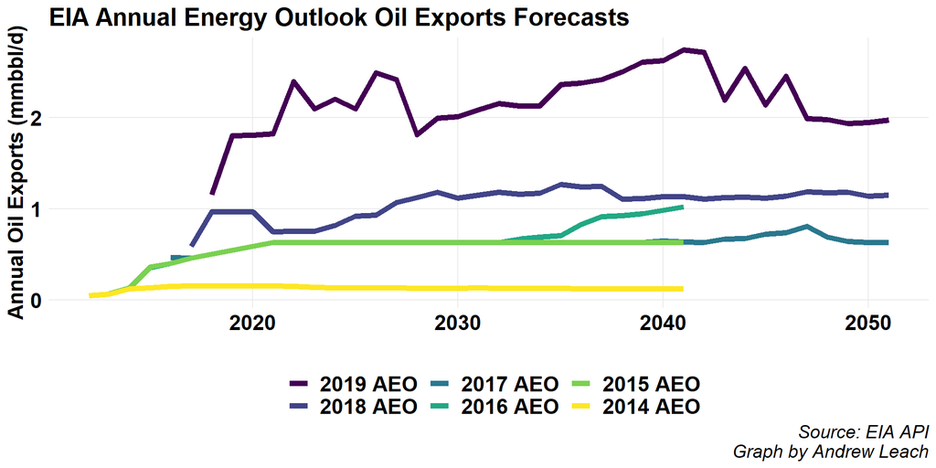

## Oil Net Imports

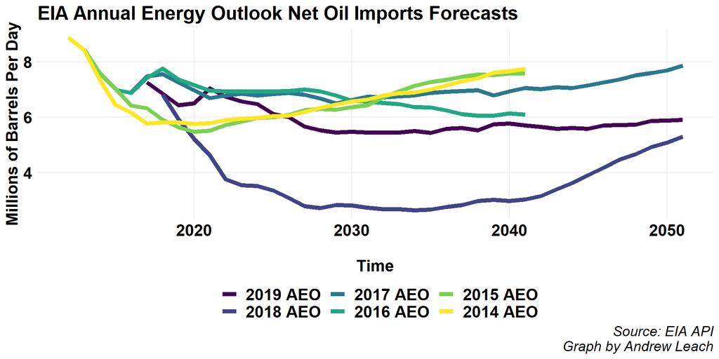

## Product Net Exports

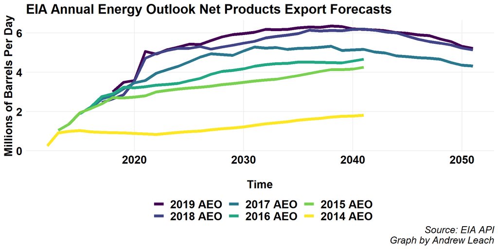